# Assignment1

Bobby den Bezemer

Tuesday, April 14, 2015

## Introduction to the dataset

This assignment deals with a dataset collected on personal movement. The data has been collected on 1 individual. It consists of two months of data that has been collected on a 5 minute interval.

## Loading and preprocessing the data

This step deals with loading and preprocessing the data. It loads the data using read.csv. Furthermore it preporcess the dates that are loaded and converts them to a date class.

```r
data <- read.csv("activity.csv")

# parsing data column as date
data$date = as.Date(strptime(data$date,
                       format = "%Y-%m-%d"))
```

## Calculating means

This step deals with calculating the mean number of steps taken each day. It furthermore plots the distribution using a histogram.

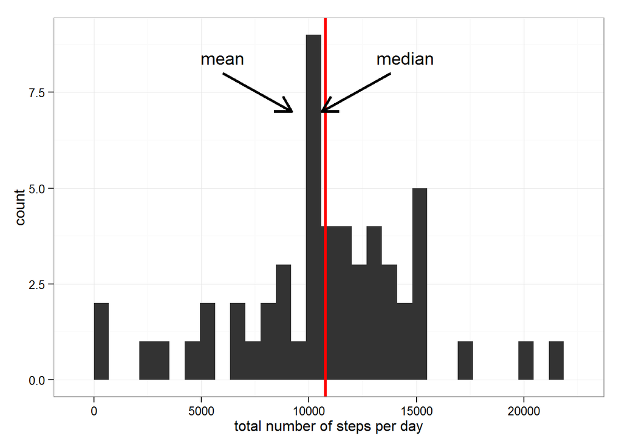

```r
# Loading the packages
library(ggplot2)
library(dplyr)
library(grid)

# group by day and compute mean per day
data_day <- data %>%
  group_by(date) %>%
  filter(!is.na(steps)) %>%
  summarise(total = sum(steps, na.rm = TRUE))

# histogram of total number of steps per day
ggplot(data = data_day, aes(x = total)) +
  geom_bar() +
  scale_x_continuous("total number of steps per day") +
  geom_vline(xintercept = mean(data_day$total, na.rm = TRUE),
             col = "red", size = 1.2) +
  geom_vline(xintercept = median(data_day$total),
             col = "red", size = 1.2) +
  geom_segment(aes(x = 6000, y = 8, xend = 9200, yend = 7)
               ,arrow = arrow(length = unit(0.5, "cm")),
               linetype = 1, size = 1.2) +
  annotate("text", x = 6000,
                y = 8.4, label = "mean", angle=0, size=5,
                colour='black', face="bold") +
  geom_segment(aes(x = 13800, y = 8, xend = 10600, yend = 7)
               ,arrow = arrow(length = unit(0.5, "cm")),
               linetype = 1, size = 1.2) +
  annotate("text", x = 14500,
                y = 8.4, label = "median", angle=0, size=5,
                colour='black', face="bold") +
  theme_bw()
```

```r
# average over all days
mean(data_day$total, na.rm = TRUE) # 9354.23
```

```
## [1] 10766
```

```r
# median of steps taken per day
median(data_day$total) # 10395
```

```
## [1] 10765
```

In this exercise, the missing values are filtered out of the analysis. If you look at the distribution of mean number of steps taken each day, it looks roughly normal. It is mostly centered around 10.000 steps.

## The average daily pattern

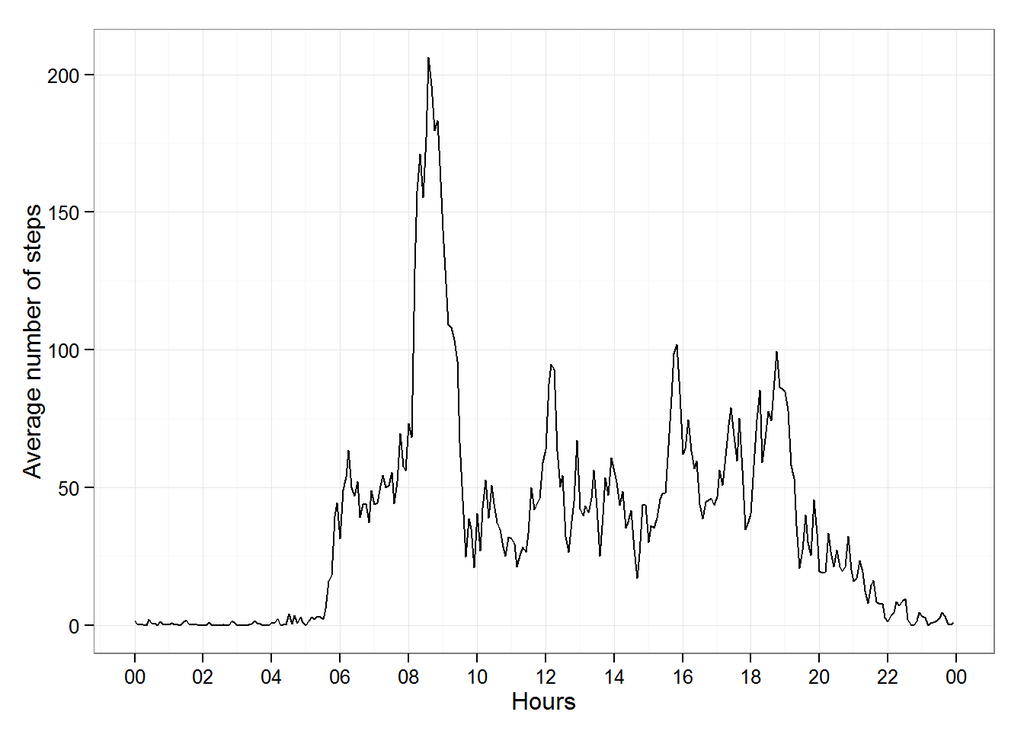

```r
# Loading required package
library(scales)

# Making a 5 minute sequence of an entire day. This sequence becomes character
num_intervals = (24 * 60) / 5 # 288 per day

times = format(seq(as.POSIXct(Sys.Date()), as.POSIXct(Sys.Date() + 1),
                   by="5 min"), "%H%M", tz = "GMT")[1:288]

# Adding this interval to every day of the data frame
data$daily_interval = rep(times, times = 61)

# now group by the daily interval variable
data_interval <- data %>%
  group_by(daily_interval) %>%
  summarise(average = mean(steps,na.rm = TRUE))

# Make a time series plot. The x variable is stripped to POSIXt
ggplot(data = data_interval, aes( x = strptime(daily_interval, "%H%M"),
                                  y = average, group = 1))  +
  geom_line() +
  # the x axis is then formatted to 2 hourly breaks.
  # for the labels I only want the hours
  scale_x_datetime("Hours", breaks = date_breaks("2 hours"),
                   labels = date_format("%H")) +
  scale_y_continuous("Average number of steps") +
  theme_bw()
```

As you can see, the maximum average number of steps is between 8 and 10 in the morning. Some other peaks are around noon, the late afternoon and the early evening.

```r
## Show the top 5 time intervals
data_interval %>%
  arrange(desc(average)) %>%
  slice(1:5)
```

```
## Source: local data frame [5 x 2]
##
##   daily_interval average
## 1           0835   206.2
## 2           0840   195.9
## 3           0850   183.4
## 4           0845   179.6
## 5           0830   177.3
```

Above it plotted the top 5 intervals in terms of number of steps taken. As you can see, the top interval is from 8.35-8.40. All other top intervals are all in the 8.30-9.00 range.

## Imputing missing values

This section deals with imputing the missing values for steps. It used the mean value per interval to impute these missing values.

```r
# calculate number of missing values
num_missing = sum(is.na(data$steps)) # 2304 intervals have missing data

# impute mean per interval
data_mean <- data %>%
  group_by(interval) %>%
  summarise(med = mean(steps, na.rm = TRUE))


# find rows where steps is na and match them with imputed values
data$steps[is.na(data$steps)] = data_mean[match(data$interval[is.na(data$steps)], data_mean$interval),2][[1]]
```

## Differences in activity patterns on weekends and weekdays

This section deals with the difference in activity patttern between weekdays and the weekend.

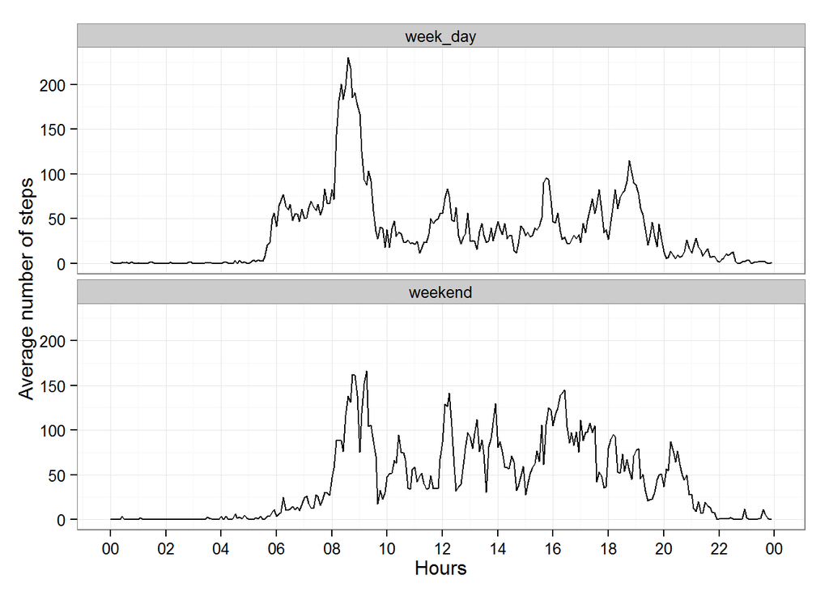

```r
# getting the days of the week and making a factor variable for weekend
# or weekday
week_day <- weekdays(data$date)
weekend = c("zondag","zaterdag")
week_day = ifelse(week_day %in% weekend, "weekend", "week_day")
data$week_day = factor(week_day)

# group by interval again
data_interval <- data %>%
  group_by(daily_interval,week_day) %>%
  summarise(average = mean(steps, na.rm = TRUE))

# Making time series plot for weekdays and weekends
ggplot(data_interval, aes( x = strptime(daily_interval, "%H%M"),
                           y = average, group = 1))  +
  geom_line() +
  # the x axis is then formatted to 2 hourly breaks.
  # for the labels I only want the hours
  scale_x_datetime("Hours", breaks = date_breaks("2 hours"),
                   labels = date_format("%H")) +
  scale_y_continuous("Average number of steps") +
  facet_wrap(~week_day, nrow = 2) +
  theme_bw()
```

As you can see on the panel plot above, the activity pattern on a weekday has a much higher peak. Here there is a sharp peak between 8 and 9. On weekends there is less of a peak. There exists a more gradual pattern that slowly fades in the wake of evening.